# Lab 8: Data Frame Functions

Author

Agustin Fleisher

```r
library(tidyverse)
library(palmerpenguins)
library(janitor)
library(RColorBrewer)
```

## Function to Standardize Variables in a Data Frame

Last week, you wrote a `rescale_01()` function which would rescale the values of a numeric variable to be between 0 and 1. This function worked on vectors, so to use it we needed to pair the function with `mutate()` if we wanted to make changes to the data. This week, we are going to use this function as a helper function for a larger `rescale_column()` function that will rescale variables in a given data frame.

**Question 1: Create a `rescale_column()` function that accepts two arguments:**

- **a data frame**
- **one or more variable names to rescale**

**The body of the function should call the original `rescale_01()` function you wrote previously and return the original data frame with those columns replaced by their rescaled versions.**

**Important**

Your function call must look like one of these two options:

```r
# Tidy (unquoted) variable names
rescale_column(df, c(height, weight))

# Quoted variable names
rescale_column(df, c("height", "weight"))
```

To achieve this, you function must use one of the `rlang` (tidy evaluation) options from class.

```r
rescale_01 <- function(x) {
  rng <- max(x, na.rm = TRUE) - min(x, na.rm = TRUE)
  if (rng == 0) {
    return(x * 0)
  }
  (x - min(x, na.rm = TRUE)) / rng
}

rescale_column <- function(df, cols) {
  df |>
    mutate(across({{ cols }}, rescale_01))
}
```

**Test Your Function:** Use your `rescale_column()` function to rescale the `bill_length_mm`, `bill_depth_mm`, `flipper_length_mm`, and `body_mass_g` columns of the `penguins` dataset. *Note:* You may need to change the function inputs if you chose to use a character vector.

```r
rescale_column(penguins,
               cols = c(bill_length_mm, bill_depth_mm, flipper_length_mm, body_mass_g)
               )
```

```
# A tibble: 344 × 8
   species island    bill_length_mm bill_depth_mm flipper_length_mm body_mass_g
   <fct>   <fct>              <dbl>         <dbl>             <dbl>       <dbl>
 1 Adelie  Torgersen         0.255          0.667             0.153       0.292
 2 Adelie  Torgersen         0.269          0.512             0.237       0.306
 3 Adelie  Torgersen         0.298          0.583             0.390       0.153
 4 Adelie  Torgersen        NA             NA                NA          NA
 5 Adelie  Torgersen         0.167          0.738             0.356       0.208
 6 Adelie  Torgersen         0.262          0.893             0.305       0.264
 7 Adelie  Torgersen         0.247          0.560             0.153       0.257
 8 Adelie  Torgersen         0.258          0.774             0.390       0.549
 9 Adelie  Torgersen         0.0727         0.595             0.356       0.215
10 Adelie  Torgersen         0.36           0.845             0.305       0.431
# ℹ 334 more rows
# ℹ 2 more variables: sex <fct>, year <int>
```

## Function to Create a Table

We’ve started to get more sophisticated with making tables, so let’s see if we can take these skills and create a function that outputs a pivoted table of counts.

**Question 2: Write a `pivot_table()` function which takes in two categorical variables, counts the number of observations in each group, and outputs a table of counts that has been pivoted wider.**

**Your function should accept three arguments:**

- **a data frame**
- **a row variable (categorical variable to appear in the rows)**
- **a column variable (categorical variable to appear in the columns)**

**Your function should:**

- **count the number of observations for each combination of the two variables**
- **pivot the results wider so that the row variable forms rows and the column variable forms columns**
- **replace any missing counts (`NA`) with 0**
- **add row and column totals using `janitor::adorn_totals()`**

**Important**

Your function call must look like one of these two options:

```r
# Tidy (unquoted) variable names
pivot_table(df, species, island)

# Quoted variable names
pivot_table(df, "species", "island")
```

To achieve this, you function must use one of the `rlang` (tidy evaluation) options from class.

```r
pivot_table <- function(df, row, col) {
  df |>
    count({{ row }}, {{ col }}) |>
    pivot_wider(
      names_from = {{ col }},
      values_from = n,
      values_fill = 0
    ) |>
    janitor::adorn_totals(where = c("row", "col"))
}
```

### Test Your Function

Use your `pivot_table()` function to display a table of counts for the `species` and `sex` of the penguins from the `penguins` dataset. *Note:* You may need to modify the names of the arguments!

```r
pivot_table(penguins, row = sex, col = species)
```

```
    sex Adelie Chinstrap Gentoo Total
 female     73        34     58   165
   male     73        34     61   168
   <NA>      6         0      5    11
  Total    152        68    124   344
```

## Function to Create a Plot

In the chapter you saw a few different types of plotting functions—creating histograms with a specified `binwidth`, checking the linearity of a scatterplot, using hexagons to avoid over plotting in a scatterplot, and sorting bars from least to greatest in a barplot.

For this section, you are going to use these functions as inspiration to write your own plotting function.

**Question 3: Your plotting function must meet the following criteria:**

- **a data frame must be the first argument**
- **two additional arguments for variables (can be numeric or categorical)**
- **the plot must map one of the variables to color (or fill)**
- **axis labels and the plot title should be descriptive (e.g., use `labs()` to replace raw variable names with human-readable labels)**
- **return a ggplot object**

You may choose the plot type (e.g., scatterplot, barplot, boxplot), as long as it meets the criteria above. You can also choose whether your function accepts quoted or unquoted variable names, but you must use one of the `rlang` (tidy evaluation) options from class.

**ImportantDouble Encoding**

If you choose to assign a `color` or `fill` aesthetic to a variable that has already been mapped to another aesthetic (e.g., `x`, `y`), then you are expected to remove the legend from your plot. Technically, your legend has redundant information that we don’t want to include in the plot!

```r
make_plot <- function(df, x_var, y_var, color_var) {
  ggplot(df, aes(x = {{ x_var }}, y = {{ y_var }}, color = {{ color_var }})) +
    geom_point() +
    labs(
      x = rlang::as_label(rlang::enquo(x_var)),
      y = rlang::as_label(rlang::enquo(y_var)),
      color = rlang::as_label(rlang::enquo(color_var)),
      title = paste(
        "Relationship between",
        rlang::as_label(rlang::enquo(x_var)),
        "and",
        rlang::as_label(rlang::enquo(y_var))
      )
    )
}
```

### Test Your Function

Test your function using variables from the `penguins` dataset.

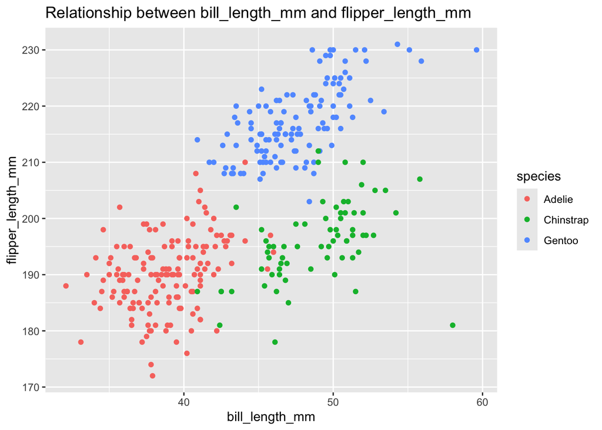

```r
make_plot(
  penguins,
  x_var = bill_length_mm,
  y_var = flipper_length_mm,
  color_var = species
)
```

## Function to Style a Plot

For this final section, I want you to write a wrapper function that can style any `ggplot` object you create.

**Question 4: Write a `style_plot()` function which accepts four arguments:**

- **a ggplot object**
- **a theme function (e.g., `theme_bw()`)**
  - **the function should set a default theme (e.g., `theme_minimal()`)**
- **a vector of colors (e.g., `RColorBrewer::brewer.pal(8, "Accent")`)**
  - **the function should set a default color palette**
- **a string indicating which aesthetic the colors should be applied to (“fill” or “color”)**

**Your function should:**

- **Apply the given (or default) theme to the plot**
- **Apply the colors to the specified aesthetic (fill or color)**
- **Return the styled plot**

```r
style_plot <- function(plot_obj,
                       theme_fn = ggplot2::theme_minimal,
                       palette = RColorBrewer::brewer.pal(3, "Set2"),
                       aesthetic = "color") {
  if (aesthetic == "fill") {
    scale_layer <- scale_fill_manual(values = palette)
  } else {
    scale_layer <- scale_color_manual(values = palette)
  }

  plot_obj +
    theme_fn() +
    scale_layer
}
```

### Test Your Function

Carry out the two tests below for your `style_plot()` function. *Note:* You may need to modify the names of the arguments!

**Test 1:** My plot

I’ve created a barplot that is stored as `my_plot`. Test your function using this plot.

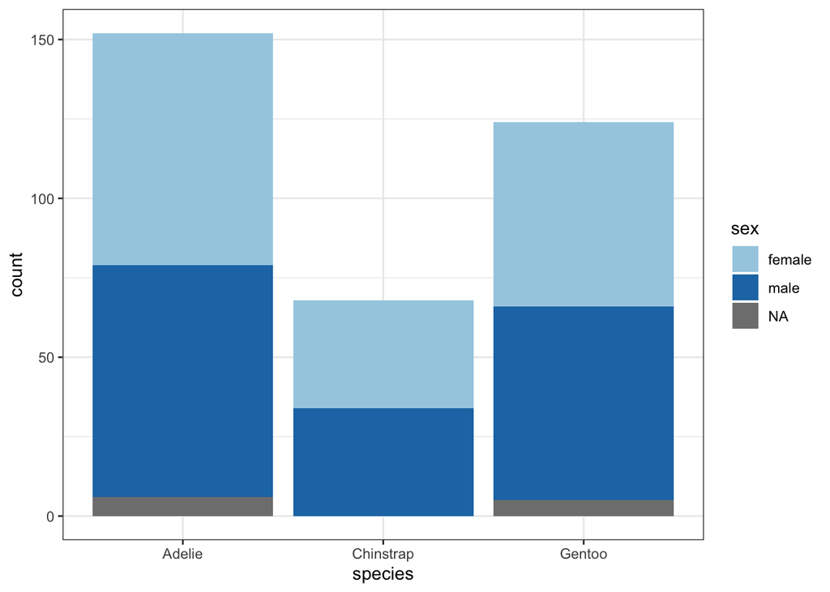

```r
my_plot <- ggplot(penguins, mapping = aes(x = species, fill = sex)) +
  geom_bar()

style_plot(my_plot,
           theme_fn = theme_bw,
           palette = brewer.pal(3, "Paired"),
           aesthetic = "fill")
```

**Test 2:** Your plot

Copy the code from your test of your plotting function (@plot-function-test) and use your `style_plot()` function to style the plot! Your test **should not** save any objects!

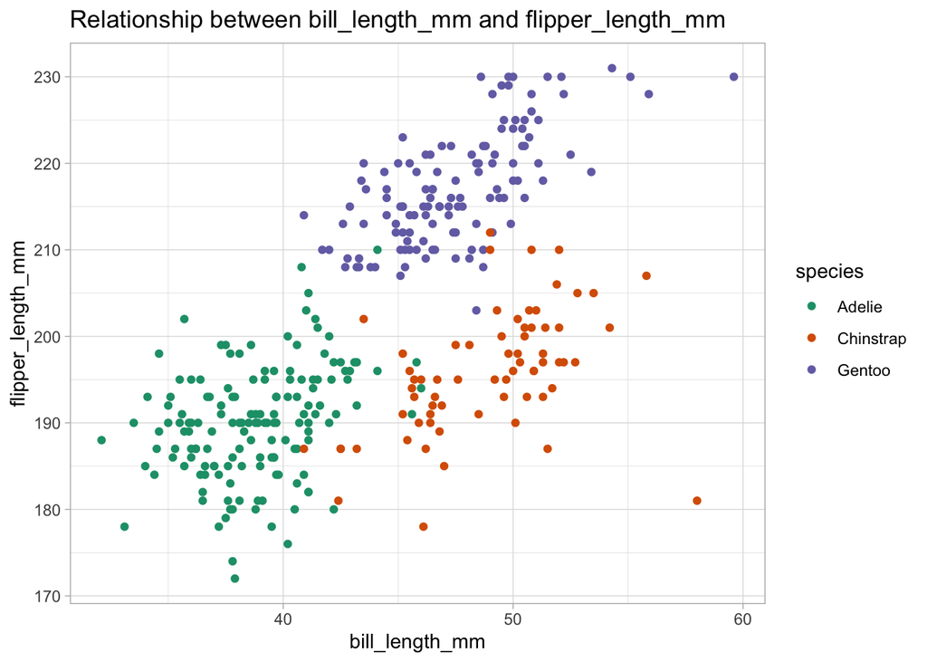

```r
make_plot(
  penguins,
  x_var = bill_length_mm,
  y_var = flipper_length_mm,
  color_var = species
) |>
  style_plot(
    theme_fn = theme_light,
    palette = brewer.pal(3, "Dark2"),
    aesthetic = "color"
  )
```